# MPDW Pertemuan 3

Fedora

2023-09-18

## Library yang digunakan

```r
library(dLagM)
library(dynlm)
library(MLmetrics)
library(lmtest)
library(car)
```

## Import Data

```r
data<-Import("https://raw.githubusercontent.com/ffddrraaa/tugas-mk-mpdw/main/Penugasan/Pertemuan%203/Californa%20(Napa)_Wine_Production_1980_2020.csv")
flip <- function(data){
  new <- data[rev(rownames(data)),]
  rownames(new) <- NULL
  new
}
data.wine <- flip(data)

t<-data.wine$Tahun
Xt<-data.wine$HarvestedAcres
Yt<-data.wine$`Price(Dollars/Unit)`
datalag<-cbind(t,Xt,Yt)
data_lag<-as.data.frame(datalag)
data_lag
```

```
##       t    Xt      Yt
## 1  1980 45200 4646.48
## 2  1981 44200 5862.26
## 3  1982 43400 5614.05
## 4  1983 43600 5287.55
## 5  1984 43400 4768.02
## 6  1985 43000 4410.76
## 7  1986 43600 4061.43
## 8  1987 43600 3749.91
## 9  1988 43200 3585.99
## 10 1989 43600 3470.84
## 11 1990 43300 3265.35
## 12 1991 43031 3462.25
## 13 1992 42870 3451.57
## 14 1993 42338 3256.77
```

[output cut: 27 more lines]

## Pembagian data

```r
#SPLIT DATA
train<-data_lag[1:33,]
test<-data_lag[34:41,]

#data time series
train.ts<-ts(train)
test.ts<-ts(test)
data.ts<-ts(data)
```

## Model Koyck

Model Koyck didasarkan pada asumsi bahwa semakin jauh jarak lag peubah independen dari periode sekarang maka semakin kecil pengaruh peubah lag terhadap peubah dependen.

Koyck mengusulkan suatu metode untuk menduga model dinamis distributed lag dengan mengasumsikan bahwa semua koefisien $\beta$ mempunyai tanda sama.

Model kyock merupakan jenis paling umum dari model infinite distributed lag dan juga dikenal sebagai geometric lag

$$y_t=a(1-\lambda)+\beta_0X_t+\beta_1Z_t+\lambda Y_{t-1}+V_t$$

dengan
$$V_t=u_t-\lambda
u_{t-1}$$

### Pemodelan

```r
#MODEL KOYCK
model.koyck <- koyckDlm(x = train$Xt, y = train$Yt)
summary(model.koyck)
```

```
##
## Call:
## "Y ~ (Intercept) + Y.1 + X.t"
##
## Residuals:
##    Min     1Q Median     3Q    Max
## -271.1 -122.0  -46.1   72.0 1344.7
##
## Coefficients:
##               Estimate Std. Error t value Pr(>|t|)
## (Intercept) -946.41663  492.04962  -1.923   0.0643 .
## Y.1            0.85565    0.07924  10.798 1.12e-11 ***
## X.t            0.03367    0.01830   1.840   0.0761 .
## ---
## Signif. codes:  0 '***' 0.001 '**' 0.01 '*' 0.05 '.' 0.1 ' ' 1
##
## Residual standard error: 283.5 on 29 degrees of freedom
## Multiple R-Squared: 0.9609,  Adjusted R-squared: 0.9582
## Wald test:   357 on 2 and 29 DF,  p-value: < 2.2e-16
##
## Diagnostic tests:
## NULL
##
##                              alpha       beta      phi
## Geometric coefficients:  -6556.492 0.03366962 0.855652
```

```r
AIC(model.koyck)
```

```
## [1] 457.0778
```

```r
BIC(model.koyck)
```

```
## [1] 462.9408
```

### Peramalan dan Akurasi

Berikut adalah hasil peramalan y untuk 8 periode kedepan menggunakan model koyck

```r
fore.koyck <- forecast(model = model.koyck, x=test$Xt, h=8)
fore.koyck
```

```
## $forecasts
## [1]  869.24258  728.41857  541.82877  353.25062  205.83258   43.43186 -163.40460
## [8] -336.71463
##
## $call
## forecast.koyckDlm(model = model.koyck, x = test$Xt, h = 8)
##
## attr(,"class")
## [1] "forecast.koyckDlm" "dLagM"
```

```r
mape.koyck <- MAPE(fore.koyck$forecasts, test$Yt)
#akurasi data training
GoF(model.koyck)
```

```
##              n      MAE           MPE       MAPE      sMAPE      MASE      MSE
## model.koyck 32 147.6858 -5.881011e-05 0.05018261 0.05124252 0.8287433 72824.31
##                 MRAE     GMRAE
## model.koyck 1.176107 0.6702604
```

## Regression with Distributed Lag

Pemodelan model Regression with Distributed Lag dengan `R` dapat menggunakan `dLagM::dlm()` . Fungsi umum dari `dlm` adalah sebagai berikut.

```r
dlm(formula , data , x , y , q , remove )
```

Fungsi `dlm()` akan menerapkan model lag terdistribusi dengan satu atau lebih prediktor. Nilai `x` dan `y` tidak perlu sebagai objek *time series* (`ts`). $q$ adalah integer yang mewakili panjang *lag* yang terbatas.

### Pemodelan (Lag=2)

```r
model.dlm <- dlm(x = train$Xt,y = train$Yt , q = 2)
summary(model.dlm)
```

```
##
## Call:
## lm(formula = model.formula, data = design)
##
## Residuals:
##    Min     1Q Median     3Q    Max
## -718.4 -393.4  -74.8  115.2 1399.2
##
## Coefficients:
##               Estimate Std. Error t value Pr(>|t|)
## (Intercept) -5239.9930   661.7859  -7.918 1.64e-08 ***
## x.t             0.2140     0.1298   1.649   0.1108
## x.1            -0.3798     0.2397  -1.584   0.1248
## x.2             0.3751     0.1435   2.613   0.0145 *
## ---
## Signif. codes:  0 '***' 0.001 '**' 0.01 '*' 0.05 '.' 0.1 ' ' 1
##
## Residual standard error: 527.8 on 27 degrees of freedom
## Multiple R-squared:  0.8503, Adjusted R-squared:  0.8337
## F-statistic: 51.12 on 3 and 27 DF,  p-value: 2.901e-11
##
## AIC and BIC values for the model:
##        AIC      BIC
## 1 482.3549 489.5248
```

```r
AIC(model.dlm)
```

```
## [1] 482.3549
```

```r
BIC(model.dlm)
```

```
## [1] 489.5248
```

$$\hat{Y_t}=-5239.9930+0.2140X_t-0.3798X_{t-1}+0.3751X_{t-2}$$
### Peramalan dan Akurasi

Berikut merupakan hasil peramalan $y$ untuk 8 periode kedepan

```r
fore.dlm <- forecast(model = model.dlm, x=test$Xt, h=8)
fore.dlm
```

```
## $forecasts
## [1]  302.5844  643.8875  621.5667  689.2886  367.8621 -342.0578 -209.1955
## [8]  175.8413
##
## $call
## forecast.dlm(model = model.dlm, x = test$Xt, h = 8)
##
## attr(,"class")
## [1] "forecast.dlm" "dLagM"
```

```r
mape.dlm <- MAPE(fore.dlm$forecasts, test$Yt)
#akurasi data training
GoF(model.dlm)
```

```
##            n      MAE         MPE      MAPE     sMAPE     MASE      MSE
## model.dlm 31 356.1482 -0.01620267 0.1219825 0.1237436 2.025054 242650.5
##               MRAE    GMRAE
## model.dlm 3.396927 1.326724
```

### *Lag* Optimum

```r
#penentuan lag optimum
finiteDLMauto(formula = Yt ~ Xt,
              data = data.frame(train), q.min = 1, q.max = 10,
              model.type = "dlm", error.type = "AIC", trace = FALSE)
```

```
##    q - k    MASE      AIC      BIC   GMRAE    MBRAE R.Adj.Sq   Ljung-Box
## 10    10 0.49905 297.2498 312.0112 0.52599 -0.72407  0.97989 0.006204722
```

```r
#penentuan lag optimum
lagop <- finiteDLMauto(formula=Yt ~ Xt,
              data = data.frame(train),model.type = "dlm",error.type = "AIC");lagop
```

```
##    q - k    MASE      AIC      BIC   GMRAE    MBRAE R.Adj.Sq   Ljung-Box
## 10    10 0.49905 297.2498 312.0112 0.52599 -0.72407  0.97989 0.006204722
```

Berdasarkan output tersebut, lag optimum didapatkan ketika lag=10. Selanjutnya dilakukan pemodelan untuk lag=10

```r
#model dlm dengan lag optimum
model.dlm2 <- dlm(x = train$Xt,y = train$Yt , q = 10)
summary(model.dlm2)
```

```
##
## Call:
## lm(formula = model.formula, data = design)
##
## Residuals:
##      Min       1Q   Median       3Q      Max
## -169.269  -39.657   -3.726   48.780  196.201
##
## Coefficients:
##               Estimate Std. Error t value Pr(>|t|)
## (Intercept) -4.197e+03  3.444e+02 -12.187 9.92e-08 ***
## x.t          2.159e-02  4.323e-02   0.499    0.627
## x.1          1.447e-02  9.511e-02   0.152    0.882
## x.2          3.434e-02  1.121e-01   0.306    0.765
## x.3          1.775e-03  1.169e-01   0.015    0.988
## x.4          4.680e-02  1.235e-01   0.379    0.712
## x.5          2.858e-02  1.240e-01   0.231    0.822
## x.6          4.166e-02  1.225e-01   0.340    0.740
## x.7         -4.669e-02  1.159e-01  -0.403    0.695
## x.8          5.055e-02  1.051e-01   0.481    0.640
## x.9         -6.043e-02  9.893e-02  -0.611    0.554
## x.10         3.925e-02  5.577e-02   0.704    0.496
## ---
## Signif. codes:  0 '***' 0.001 '**' 0.01 '*' 0.05 '.' 0.1 ' ' 1
##
## Residual standard error: 127.3 on 11 degrees of freedom
## Multiple R-squared:  0.9899, Adjusted R-squared:  0.9799
## F-statistic: 98.46 on 11 and 11 DF,  p-value: 2.388e-09
##
## AIC and BIC values for the model:
##        AIC      BIC
## 1 297.2498 312.0112
```

```r
AIC(model.dlm2)
```

```
## [1] 297.2498
```

```r
BIC(model.dlm2)
```

```
## [1] 312.0112
```

```r
#peramalan dan akurasi
fore.dlm2 <- forecast(model = model.dlm2, x=test$Xt, h=8)
mape.dlm2<- MAPE(fore.dlm2$forecasts, test$Yt)
#akurasi data training
GoF(model.dlm2)
```

```
##             n      MAE           MPE       MAPE      sMAPE      MASE      MSE
## model.dlm2 23 66.40551 -0.0009984145 0.02882678 0.02879058 0.4990457 7751.124
##                MRAE     GMRAE
## model.dlm2 1.786809 0.5259874
```

Model tersebut merupakan model yang sangat baik dengan nilai MAPE yang kurang dari 10%.

## Model Autoregressive

Peubah dependen dipengaruhi oleh peubah independen pada waktu sekarang, serta dipengaruhi juga oleh peubah dependen itu sendiri pada satu waktu yang lalu maka model tersebut disebut *autoregressive* (Gujarati 2004).

### Pemodelan

```r
model.ardl <- ardlDlm(x = train$Xt, y = train$Yt, p = 1 , q = 1)
summary(model.ardl)
```

```
##
## Time series regression with "ts" data:
## Start = 2, End = 33
##
## Call:
## dynlm(formula = as.formula(model.text), data = data, start = 1)
##
## Residuals:
##     Min      1Q  Median      3Q     Max
## -252.37 -151.12  -29.64   58.76 1307.76
##
## Coefficients:
##               Estimate Std. Error t value Pr(>|t|)
## (Intercept) -947.46130  484.32268  -1.956   0.0605 .
## X.t           -0.04362    0.05518  -0.791   0.4359
## X.1            0.07592    0.05701   1.332   0.1937
## Y.1            0.86051    0.07704  11.170 7.92e-12 ***
## ---
## Signif. codes:  0 '***' 0.001 '**' 0.01 '*' 0.05 '.' 0.1 ' ' 1
##
## Residual standard error: 278.9 on 28 degrees of freedom
## Multiple R-squared:  0.9635, Adjusted R-squared:  0.9595
## F-statistic: 246.1 on 3 and 28 DF,  p-value: < 2.2e-16
```

```r
AIC(model.ardl)
```

```
## [1] 456.9106
```

```r
BIC(model.ardl)
```

```
## [1] 464.2393
```

$$\hat{Y}=-947.46130-0.04362X_t+0.07592X_{t-1}+0.86051Y_{t-1}$$

### Peramalan dan Akurasi

```r
fore.ardl <- forecast(model = model.ardl, x=test$Xt, h=8)
fore.ardl
```

```
## $forecasts
## [1]  854.04523  780.65849  703.14562  524.88342  288.21434  162.96623   61.35863
## [8] -183.88369
##
## $call
## forecast.ardlDlm(model = model.ardl, x = test$Xt, h = 8)
##
## attr(,"class")
## [1] "forecast.ardlDlm" "dLagM"
```

Data di atas merupakan hasil peramalan untuk 8 periode ke depan menggunakan Model Autoregressive dengan $p=1$ dan $q=1$.

```r
mape.ardl <- MAPE(fore.ardl$forecasts, test$Yt)
mape.ardl
```

```
## [1] 0.5094805
```

```r
#akurasi data training
GoF(model.ardl)
```

```
##             n      MAE         MPE       MAPE      sMAPE      MASE     MSE
## model.ardl 32 139.9641 0.002627015 0.04729743 0.04812626 0.7854125 68055.6
##                MRAE     GMRAE
## model.ardl 1.097211 0.6413289
```

### *Lag* Optimum

```r
#penentuan lag optimum
model.ardl.opt <- ardlBoundOrders(data = data.frame(data_lag), ic = "AIC",
                                  formula = Yt ~ Xt )
min_p=c()
for(i in 1:15){
  min_p[i]=min(model.ardl.opt$Stat.table[[i]])
}
q_opt=which(min_p==min(min_p, na.rm = TRUE))
p_opt=which(model.ardl.opt$Stat.table[[q_opt]] ==
              min(model.ardl.opt$Stat.table[[q_opt]], na.rm = TRUE))
data.frame("q_optimum" = q_opt, "p_optimum" = p_opt,
           "AIC"=model.ardl.opt$min.Stat)
```

```
##   q_optimum p_optimum      AIC
## 1         3        14 121.0013
```

Dari tabel di atas, dapat terlihat bahwa nilai AIC terendah didapat ketika $p=14$ dan $q=3$, yaitu sebesar `121.0013`. Artinya, model autoregressive optimum didapat ketika $p=14$ dan $q=3$.

Selanjutnya dapat dilakukan pemodelan dengan nilai $p$ dan $q$ optimum seperti inisialisasi di langkah sebelumnya.

```r
#ARDL MODEL
model.ardl = ardlDlm(x = train$Xt, y = train$Yt, p = 14 , q = 3)
summary(model.ardl)
```

```
##
## Time series regression with "ts" data:
## Start = 15, End = 33
##
## Call:
## dynlm(formula = as.formula(model.text), data = data, start = 1)
##
## Residuals:
## ALL 19 residuals are 0: no residual degrees of freedom!
##
## Coefficients:
##               Estimate Std. Error t value Pr(>|t|)
## (Intercept) -8.364e+03        NaN     NaN      NaN
## X.t          5.260e-02        NaN     NaN      NaN
## X.1          6.055e-02        NaN     NaN      NaN
## X.2         -1.247e-01        NaN     NaN      NaN
## X.3          1.635e-01        NaN     NaN      NaN
## X.4         -7.919e-02        NaN     NaN      NaN
## X.5          2.028e-01        NaN     NaN      NaN
## X.6         -2.075e-02        NaN     NaN      NaN
## X.7          5.672e-02        NaN     NaN      NaN
## X.8         -5.676e-03        NaN     NaN      NaN
## X.9          7.709e-03        NaN     NaN      NaN
## X.10        -1.761e-02        NaN     NaN      NaN
## X.11         1.524e-02        NaN     NaN      NaN
## X.12         8.657e-02        NaN     NaN      NaN
## X.13        -5.025e-02        NaN     NaN      NaN
## X.14        -2.585e-03        NaN     NaN      NaN
## Y.1         -5.874e-01        NaN     NaN      NaN
## Y.2          1.149e+00        NaN     NaN      NaN
## Y.3         -1.585e+00        NaN     NaN      NaN
##
## Residual standard error: NaN on 0 degrees of freedom
## Multiple R-squared:      1,  Adjusted R-squared:    NaN
## F-statistic:   NaN on 18 and 0 DF,  p-value: NA
```

```r
model.ardl1 = ardlDlm(x = train$Xt, y = train$Yt, p = 7 , q = 10)
summary(model.ardl1)
```

```
##
## Time series regression with "ts" data:
## Start = 11, End = 33
##
## Call:
## dynlm(formula = as.formula(model.text), data = data, start = 1)
##
## Residuals:
##        11        12        13        14        15        16        17        18
##   1.86302  -1.34773   9.13100  -2.56579  -1.22922  -1.30042   0.09757  13.65223
##        19        20        21        22        23        24        25        26
##  -9.74746  -1.97834 -11.57263   1.77443  -1.52436  -3.10704   7.02627  -1.82914
##        27        28        29        30        31        32        33
##  14.63360 -15.37348  -8.88527  -7.00891  -7.10207  43.77520 -17.38147
##
## Coefficients:
##               Estimate Std. Error t value Pr(>|t|)
## (Intercept) -8.866e+03  2.277e+03  -3.893   0.0176 *
## X.t          3.627e-02  1.178e-02   3.080   0.0369 *
## X.1         -7.097e-03  2.828e-02  -0.251   0.8142
## X.2          1.400e-02  3.743e-02   0.374   0.7273
## X.3          2.611e-02  4.232e-02   0.617   0.5706
## X.4          6.957e-02  4.118e-02   1.690   0.1664
## X.5          1.127e-01  5.139e-02   2.194   0.0933 .
## X.6          5.377e-02  3.919e-02   1.372   0.2420
## X.7          4.803e-02  3.810e-02   1.260   0.2760
## Y.1         -1.687e-01  2.762e-01  -0.611   0.5743
## Y.2         -5.394e-01  1.777e-01  -3.035   0.0386 *
## Y.3         -5.316e-01  2.941e-01  -1.808   0.1449
## Y.4         -2.813e-01  1.858e-01  -1.514   0.2046
## Y.5         -2.696e-01  1.853e-01  -1.455   0.2193
## Y.6          2.485e-01  1.236e-01   2.010   0.1148
## Y.7          1.366e-01  1.456e-01   0.938   0.4013
## Y.8          2.167e-01  1.308e-01   1.656   0.1730
## Y.9          5.600e-02  1.804e-01   0.310   0.7718
## Y.10         4.498e-02  6.439e-02   0.699   0.5233
## ---
## Signif. codes:  0 '***' 0.001 '**' 0.01 '*' 0.05 '.' 0.1 ' ' 1
##
## Residual standard error: 29.3 on 4 degrees of freedom
## Multiple R-squared:  0.9998, Adjusted R-squared:  0.9989
## F-statistic:  1148 on 18 and 4 DF,  p-value: 1.685e-06
```

```r
AIC(model.ardl1)
```

```
## [1] 220.4016
```

```r
BIC(model.ardl1)
```

```
## [1] 243.1115
```

### ARDL Forecasting

```r
(fore.ardl <- forecast(model = model.ardl1, x=test$Xt, h=8))
```

```
## $forecasts
## [1]  770.2518  587.5549  515.4802  629.8843  825.3322  619.4317  149.1842
## [8] -245.7382
##
## $call
## forecast.ardlDlm(model = model.ardl1, x = test$Xt, h = 8)
##
## attr(,"class")
## [1] "forecast.ardlDlm" "dLagM"
```

### ARDL Accuracy

```r
# mape akurasi testing
mape.ardl <- MAPE(fore.ardl$forecasts, test$Yt) #data testing

# mape akurasi data training
mape_train <- GoF(model.ardl1)["MAPE"]

c("MAPE_testing" = mape.ardl, "MAPE_training" = mape_train)
```

```
## $MAPE_testing
## [1] 0.4178113
##
## $MAPE_training.MAPE
## [1] 0.005517887
```

## Perbandingan 3 Metode

```r
akurasi <- matrix(c(mape.koyck, mape.dlm, mape.ardl))
row.names(akurasi)<- c("Koyck","DLM","Autoregressive")
colnames(akurasi) <- c("MAPE")
akurasi
```

```
##                     MAPE
## Koyck          0.6695126
## DLM            0.6260180
## Autoregressive 0.4178113
```

Berdasarkan nilai MAPE, model paling optimum didapat pada Model Autoregressive karena memiliki nilai MAPE yang terkecil.

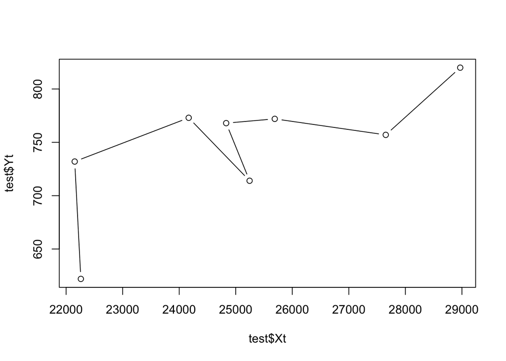

```r
par(mfrow=c(1,1))
plot(test$Xt, test$Yt, type="b", col="black")
```

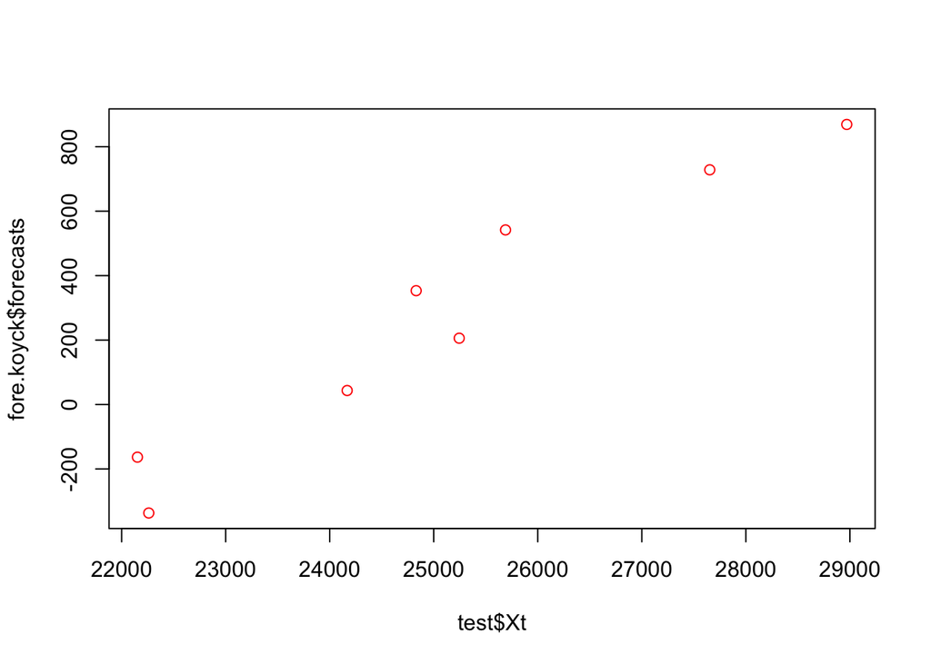

```r
plot(test$Xt, fore.koyck$forecasts,col="red")
```

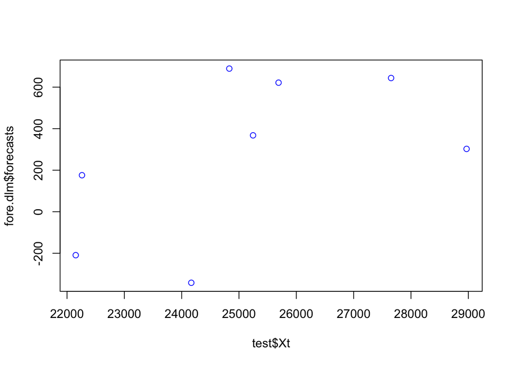

```r
plot(test$Xt, fore.dlm$forecasts,col="blue")
```

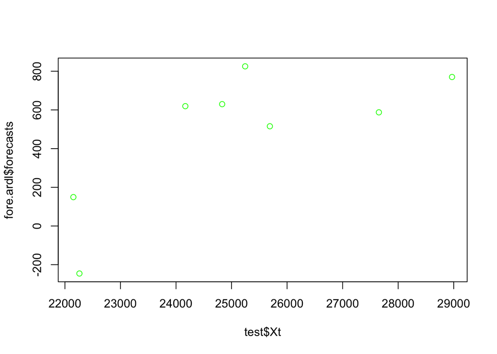

```r
plot(test$Xt, fore.ardl$forecasts,col="green")
```

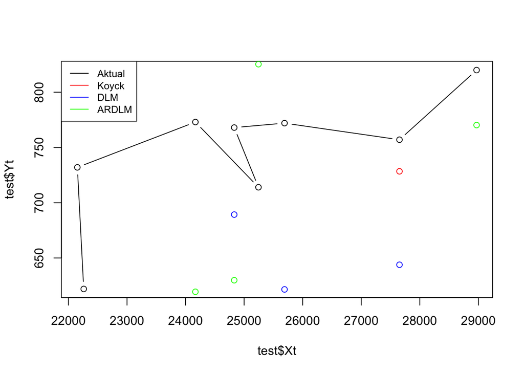

```r
plot(test$Xt, test$Yt, type="b", col="black")
points(test$Xt, fore.koyck$forecasts,col="red")
points(test$Xt, fore.dlm$forecasts,col="blue")
points(test$Xt, fore.ardl$forecasts,col="green")
legend("topleft",c("Aktual", "Koyck","DLM", "ARDLM"), lty=1, col=c("black","red","blue","green"), cex=0.8)
```

Hasil dari visualisasi di atas menunjukkan bahwa model ARDLM merupakan metode yang paling sesuai untuk peramalan data wine karena memiliki pola data aktual, walaupun masih sangat jauh. Kurangnya data testing membuat hasil kurang maksimal oleh karena itu perlu ditambahkan kembali data testing yang digunakan.